# Исследование объявлений о продаже квартир

В нашем распоряжении данные сервиса Яндекс.Недвижимость — архив объявлений о продаже квартир в Санкт-Петербурге и соседних населённых пунктов за несколько лет. В процессе проведения исследования необходимо определить рыночную стоимость объектов недвижимости. Основная задача исседования — установить параметры, влияющие на продажу квартир. Это позволит построить автоматизированную систему: она отследит аномалии и мошенническую деятельность.

По каждой квартире на продажу доступны два вида данных. Первые вписаны пользователем, вторые — получены автоматически на основе картографических данных. Например, расстояние до центра, аэропорта, ближайшего парка и водоёма.

**Описание данных:**

- **airports_nearest** — расстояние до ближайшего аэропорта в метрах (м)
- **balcony** — число балконов
- **ceiling_height** — высота потолков (м)
- **cityCenters_nearest** — расстояние до центра города (м)
- **days_exposition** — сколько дней было размещено объявление (от публикации до снятия)
- **first_day_exposition** — дата публикации
- **floor** — этаж
- **floors_total** — всего этажей в доме
- **is_apartment** — апартаменты (булев тип)
- **kitchen_area** — площадь кухни в квадратных метрах (м²)
- **last_price** — цена на момент снятия с публикации
- **living_area** — жилая площадь в квадратных метрах (м²)
- **locality_name** — название населённого пункта
- **open_plan** — свободная планировка (булев тип)
- **parks_around3000** — число парков в радиусе 3 км
- **parks_nearest** — расстояние до ближайшего парка (м)
- **ponds_around3000** — число водоёмов в радиусе 3 км
- **ponds_nearest** — расстояние до ближайшего водоёма (м)
- **rooms** — число комнат
- **studio** — квартира-студия (булев тип)
- **total_area** — общая площадь квартиры в квадратных метрах (м²)
- **total_images** — число фотографий квартиры в объявлении

**Цель исследования:**

- Получить информацию о времени продажи квартиры.
- Найти факторы, которые большего всего влияют на стоимость квартиры.
- Изучить предложение квартир по локации.
- Выделить и получить информацию по квартирам в центре Санкт-Петербурга.

**Ход исследования:**

В файле **"real_estate_data.csv"** содержится архив объявлений о продаже квартир в Санкт-Петербурге и соседних населённых пунктах за несколько лет.

**По каждой квартире на продажу доступны два вида данных:**

1) пользовательские;

2) получены автоматически на основе картографических данных.

Т. к. часть данных записаны пользователями, они могут содержать ошибки. Ошибки также могут быть и в данных, полученных автоматически на основе картографических данных. Для начала нужен обзор данных. Далее, буду делать предобработку данных. Искать аномалии, пропущенные значения и т.д..

**Для решения поставленных задач необходимо рассчитать и добавить в таблицу несколько показателей:**

- цена за 1 квадратный метр,
- день недели, месяц и год публикации объявления,
- этаж квартиры (первый, последний, другой).

**Таким образом, исследование пройдёт в 5 этапов:**

- Обзор данных.
- Предобработка данных.
- Расчёты и добавление результатов в таблицу.
- Исследовательский анализ данных.
- Выводы

## Открываем файл с данными и изучаем общую информацию

### Импортируем библиотеки для работы с файлами

```python
# импортируем необходимые дляработы библиотеки

import pandas as pd
import numpy as np
import matplotlib.pyplot as plt
import seaborn as sns
```

### Загружаем данные из csv-файла в датафрейм c помощью библиотеки pandas.

```python
# для исключения ошибок загрузки данных воспльзуемя методом "try - except"

try:
    data = pd.read_csv('/datasets/real_estate_data.csv', sep='\t')
except:
    data = pd.read_csv('https://code.s3.yandex.net/datasets/real_estate_data.csv', sep='\t')
```

### Первичный взгляд на полученные данные

```python
# выведем на экран 5 строк таблицы для ознакомления

pd.set_option('display.max_columns', None)
data['last_price'] = data['last_price']/1000000
data.head()
```

|  | total_images | last_price | total_area | first_day_exposition | rooms | ceiling_height | floors_total | living_area | floor | is_apartment | studio | open_plan | kitchen_area | balcony | locality_name | airports_nearest | cityCenters_nearest | parks_around3000 | parks_nearest | ponds_around3000 | ponds_nearest | days_exposition |
| --- | --- | --- | --- | --- | --- | --- | --- | --- | --- | --- | --- | --- | --- | --- | --- | --- | --- | --- | --- | --- | --- | --- |
| 0 | 20 | 13.000 | 108.0 | 2019-03-07T00:00:00 | 3 | 2.70 | 16.0 | 51.0 | 8 | NaN | False | False | 25.0 | NaN | Санкт-Петербург | 18863.0 | 16028.0 | 1.0 | 482.0 | 2.0 | 755.0 | NaN |
| 1 | 7 | 3.350 | 40.4 | 2018-12-04T00:00:00 | 1 | NaN | 11.0 | 18.6 | 1 | NaN | False | False | 11.0 | 2.0 | посёлок Шушары | 12817.0 | 18603.0 | 0.0 | NaN | 0.0 | NaN | 81.0 |
| 2 | 10 | 5.196 | 56.0 | 2015-08-20T00:00:00 | 2 | NaN | 5.0 | 34.3 | 4 | NaN | False | False | 8.3 | 0.0 | Санкт-Петербург | 21741.0 | 13933.0 | 1.0 | 90.0 | 2.0 | 574.0 | 558.0 |
| 3 | 0 | 64.900 | 159.0 | 2015-07-24T00:00:00 | 3 | NaN | 14.0 | NaN | 9 | NaN | False | False | NaN | 0.0 | Санкт-Петербург | 28098.0 | 6800.0 | 2.0 | 84.0 | 3.0 | 234.0 | 424.0 |
| 4 | 2 | 10.000 | 100.0 | 2018-06-19T00:00:00 | 2 | 3.03 | 14.0 | 32.0 | 13 | NaN | False | False | 41.0 | NaN | Санкт-Петербург | 31856.0 | 8098.0 | 2.0 | 112.0 | 1.0 | 48.0 | 121.0 |

```python
# выведем на экран 10 случайных строк таблицы

data.sample(10)
```

|  | total_images | last_price | total_area | first_day_exposition | rooms | ceiling_height | floors_total | living_area | floor | is_apartment | studio | open_plan | kitchen_area | balcony | locality_name | airports_nearest | cityCenters_nearest | parks_around3000 | parks_nearest | ponds_around3000 | ponds_nearest | days_exposition |
| --- | --- | --- | --- | --- | --- | --- | --- | --- | --- | --- | --- | --- | --- | --- | --- | --- | --- | --- | --- | --- | --- | --- |
| 16076 | 1 | 6.30000 | 88.0 | 2018-11-02T00:00:00 | 3 | 2.60 | 9.0 | 40.0 | 1 | NaN | False | False | NaN | NaN | Всеволожск | NaN | NaN | NaN | NaN | NaN | NaN | 107.0 |
| 9951 | 11 | 16.55000 | 180.6 | 2017-07-14T00:00:00 | 3 | 3.50 | 10.0 | 83.5 | 10 | NaN | False | False | 48.0 | 1.0 | Санкт-Петербург | 39892.0 | 15176.0 | 0.0 | NaN | 0.0 | NaN | NaN |
| 9542 | 8 | 4.10000 | 46.0 | 2017-09-10T00:00:00 | 2 | 2.55 | 9.0 | 28.5 | 9 | NaN | False | False | 7.0 | 2.0 | Санкт-Петербург | 32103.0 | 12696.0 | 0.0 | NaN | 0.0 | NaN | 91.0 |
| 10361 | 5 | 28.80000 | 187.0 | 2017-04-09T00:00:00 | 3 | NaN | 15.0 | 92.5 | 3 | NaN | False | False | 34.0 | 0.0 | Санкт-Петербург | 31744.0 | 4836.0 | 0.0 | NaN | 3.0 | 153.0 | 176.0 |
| 11078 | 1 | 2.39100 | 39.9 | 2018-08-02T00:00:00 | 1 | NaN | 25.0 | 18.6 | 18 | NaN | False | False | 9.7 | NaN | посёлок Парголово | 55827.0 | 21502.0 | 0.0 | NaN | 0.0 | NaN | 25.0 |
| 21418 | 1 | 2.52757 | 42.4 | 2016-11-25T00:00:00 | 1 | 2.56 | 18.0 | 19.9 | 16 | False | False | False | NaN | NaN | Никольское | NaN | NaN | NaN | NaN | NaN | NaN | 549.0 |
| 12145 | 10 | 5.30000 | 62.0 | 2016-09-01T00:00:00 | 3 | 2.60 | 8.0 | 36.0 | 6 | False | False | False | 9.0 | 2.0 | Санкт-Петербург | 24926.0 | 16005.0 | 0.0 | NaN | 0.0 | NaN | 134.0 |
| 16725 | 9 | 6.40000 | 35.0 | 2019-04-27T00:00:00 | 1 | NaN | 18.0 | 18.0 | 5 | NaN | False | False | 10.0 | 1.0 | Санкт-Петербург | 11187.0 | 13491.0 | 0.0 | NaN | 0.0 | NaN | NaN |
| 3561 | 5 | 12.30000 | 115.0 | 2017-08-09T00:00:00 | 3 | 2.70 | 20.0 | 45.0 | 16 | NaN | False | False | 60.0 | 1.0 | Санкт-Петербург | 33386.0 | 14234.0 | 0.0 | NaN | 0.0 | NaN | 63.0 |
| 253 | 17 | 3.34000 | 37.0 | 2018-03-28T00:00:00 | 1 | NaN | 5.0 | 19.0 | 4 | NaN | False | False | 10.0 | NaN | Санкт-Петербург | 47303.0 | 25866.0 | 1.0 | 251.0 | 1.0 | 350.0 | 75.0 |

```python
# посмотрим min, max, среднее и т.д.

data.describe().T
```

|  | count | mean | std | min | 25% | 50% | 75% | max |
| --- | --- | --- | --- | --- | --- | --- | --- | --- |
| total_images | 23699.0 | 9.858475 | 5.682529 | 0.00000 | 6.00 | 9.00 | 14.0 | 50.0 |
| last_price | 23699.0 | 6.541549 | 10.887013 | 0.01219 | 3.40 | 4.65 | 6.8 | 763.0 |
| total_area | 23699.0 | 60.348651 | 35.654083 | 12.00000 | 40.00 | 52.00 | 69.9 | 900.0 |
| rooms | 23699.0 | 2.070636 | 1.078405 | 0.00000 | 1.00 | 2.00 | 3.0 | 19.0 |
| ceiling_height | 14504.0 | 2.771499 | 1.261056 | 1.00000 | 2.52 | 2.65 | 2.8 | 100.0 |
| floors_total | 23613.0 | 10.673824 | 6.597173 | 1.00000 | 5.00 | 9.00 | 16.0 | 60.0 |
| living_area | 21796.0 | 34.457852 | 22.030445 | 2.00000 | 18.60 | 30.00 | 42.3 | 409.7 |
| floor | 23699.0 | 5.892358 | 4.885249 | 1.00000 | 2.00 | 4.00 | 8.0 | 33.0 |
| kitchen_area | 21421.0 | 10.569807 | 5.905438 | 1.30000 | 7.00 | 9.10 | 12.0 | 112.0 |
| balcony | 12180.0 | 1.150082 | 1.071300 | 0.00000 | 0.00 | 1.00 | 2.0 | 5.0 |
| airports_nearest | 18157.0 | 28793.672193 | 12630.880622 | 0.00000 | 18585.00 | 26726.00 | 37273.0 | 84869.0 |
| cityCenters_nearest | 18180.0 | 14191.277833 | 8608.386210 | 181.00000 | 9238.00 | 13098.50 | 16293.0 | 65968.0 |
| parks_around3000 | 18181.0 | 0.611408 | 0.802074 | 0.00000 | 0.00 | 0.00 | 1.0 | 3.0 |
| parks_nearest | 8079.0 | 490.804555 | 342.317995 | 1.00000 | 288.00 | 455.00 | 612.0 | 3190.0 |
| ponds_around3000 | 18181.0 | 0.770255 | 0.938346 | 0.00000 | 0.00 | 1.00 | 1.0 | 3.0 |
| ponds_nearest | 9110.0 | 517.980900 | 277.720643 | 13.00000 | 294.00 | 502.00 | 729.0 | 1344.0 |
| days_exposition | 20518.0 | 180.888634 | 219.727988 | 1.00000 | 45.00 | 95.00 | 232.0 | 1580.0 |

### Выведем статистику по исходным данным

```python
data.info()
```

```
<class 'pandas.core.frame.DataFrame'>
RangeIndex: 23699 entries, 0 to 23698
Data columns (total 22 columns):
 #   Column                Non-Null Count  Dtype
---  ------                --------------  -----
 0   total_images          23699 non-null  int64
 1   last_price            23699 non-null  float64
 2   total_area            23699 non-null  float64
 3   first_day_exposition  23699 non-null  object
 4   rooms                 23699 non-null  int64
 5   ceiling_height        14504 non-null  float64
 6   floors_total          23613 non-null  float64
 7   living_area           21796 non-null  float64
 8   floor                 23699 non-null  int64
 9   is_apartment          2775 non-null   object
 10  studio                23699 non-null  bool
 11  open_plan             23699 non-null  bool
 12  kitchen_area          21421 non-null  float64
 13  balcony               12180 non-null  float64
 14  locality_name         23650 non-null  object
 15  airports_nearest      18157 non-null  float64
 16  cityCenters_nearest   18180 non-null  float64
 17  parks_around3000      18181 non-null  float64
 18  parks_nearest         8079 non-null   float64
 19  ponds_around3000      18181 non-null  float64
 20  ponds_nearest         9110 non-null   float64
 21  days_exposition       20518 non-null  float64
dtypes: bool(2), float64(14), int64(3), object(3)
memory usage: 3.7+ MB
```

**Вывод на основе описательных данных:**

1. **last_price:** - минимальная цена квартиры 12190 руб., что явно не характерно для рынка СПб и ЛО. Похоже на ошибку. Максимальная цена 763 000 000 руб. очень большая, но для исторических/элитных объектов возможна. НО! Такие значения могут плохо влиять на среднее значение, вероятно, большие данные тоже стоит исключить.
2. **rooms:** - минимальное число комнат 0 - ошибка. Как вариант это может быть квартира-студия. Нужно проверить.
3. **ceiling_height:** - минимальная высота потолков 1 метр, максимальная - 100 метров. Явно ошибка. Такие значения будем удалять.
4. **floors_total:** - max количество этажей 60 - похоже на ошибку, самое высокое здание в Санкт-Петербурге и окретностях - Лахта имеет 35 этажей. Такие объекты следует удалить.
5. **living_area:** - min жилая площадь 2 м² невозможна - ошибка. Такие объекты следует удалить.
6. **kitchen_area:** - min площадь кухни 1,3 м² невозможна - ошибка. Такие объекты следует удалить.
7. **airports_nearest:** - min расстояние до аэропорта 0 м невозможно. Два варианта событий: либо нет данных и заполнили нулем, либо ошибка. Такие объекты следует удалить.
8. **days_exposition:** - минимальное количество дней размещения объявления - 1. Продажа недвижимости за 1 день или снятие объявления по другой причине - допустимый вариант, но, если таких объявлений много, то такие данные могут негативно влиять на среднее. Максимальное значение - 1580 дней (больше 4-х лет) также может негативно влиять на среднее время.

### Проверим таблицу на наличие явных дубликатов.

```python
print('\033[1m' + 'Количество явных дубликатов в таблице:' + '\033[0m', data.duplicated().sum())
```

```
Количество явных дубликатов в таблице: 0
```

### Проверим количество пропусков

```python
data.isna().sum()
```

```
total_images                0
last_price                  0
total_area                  0
first_day_exposition        0
rooms                       0
ceiling_height           9195
floors_total               86
living_area              1903
floor                       0
is_apartment            20924
studio                      0
open_plan                   0
kitchen_area             2278
balcony                 11519
locality_name              49
airports_nearest         5542
cityCenters_nearest      5519
parks_around3000         5518
parks_nearest           15620
ponds_around3000         5518
ponds_nearest           14589
days_exposition          3181
dtype: int64
```

```python
pd.DataFrame(round(data.isna().mean()*100,)).style.background_gradient('coolwarm')
```

|  | 0 |
| --- | --- |
| total_images | 0.000000 |
| last_price | 0.000000 |
| total_area | 0.000000 |
| first_day_exposition | 0.000000 |
| rooms | 0.000000 |
| ceiling_height | 39.000000 |
| floors_total | 0.000000 |
| living_area | 8.000000 |
| floor | 0.000000 |
| is_apartment | 88.000000 |
| studio | 0.000000 |
| open_plan | 0.000000 |
| kitchen_area | 10.000000 |
| balcony | 49.000000 |
| locality_name | 0.000000 |
| airports_nearest | 23.000000 |
| cityCenters_nearest | 23.000000 |
| parks_around3000 | 23.000000 |
| parks_nearest | 66.000000 |
| ponds_around3000 | 23.000000 |
| ponds_nearest | 62.000000 |
| days_exposition | 13.000000 |

### Построим гистограмму для всех числовых столбцов таблицы на одном графике

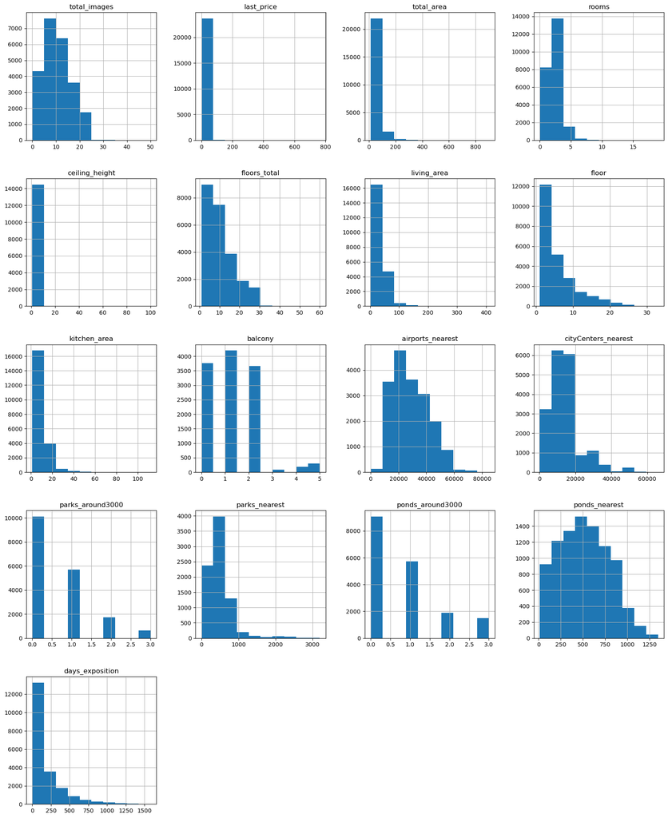

```python
# для построения гистограмм используем команду: data.hist(figsize=(20, 25)

data.hist(figsize= (20, 25))
plt.show()
```

**Вывод:**

1. Прочитал файл.
2. Необходимо изменить тип данных в столбцах:
- **last_price:** вещественное число float64 → int64
- **first_day_exposition:** строка object → datetime
- **floors_total:** вещественное число float64, по вводным данным целое число (этажей) → int64
- **is_apartment:** строка object, по вводным данным булев тип → bool
- **balcony:** вещественное число float64, по вводным данным целое число (балконов) → int64
- **parks_around3000:** вещественное число float64, по вводным данным целое число (парков) → int64
- **ponds_around3000:** вещественное число float64, по вводным данным целое число (водоемов) → int64
- **days_exposition:** вещественное число float64, по вводным данным целое число (дней) → int64
1. Большое количество пропусков в большинстве столбцов. Необходимо исправлять.
2. На основе вывода по описательным данным, буду корректировать некоторые значения.
3. Приведем названия столбцов к единому стилю.

## Предобработка данных

### Приведем имена столбцов к единому стилю

```python
# переименовываем столбцы

data = data.rename(columns={'cityCenters_nearest': 'city_centers_nearest',
                            'parks_around3000': 'parks_around_3000',
                            'ponds_around3000': 'ponds_around_3000'})
# проверим

data.head()
```

|  | total_images | last_price | total_area | first_day_exposition | rooms | ceiling_height | floors_total | living_area | floor | is_apartment | studio | open_plan | kitchen_area | balcony | locality_name | airports_nearest | city_centers_nearest | parks_around_3000 | parks_nearest | ponds_around_3000 | ponds_nearest | days_exposition |
| --- | --- | --- | --- | --- | --- | --- | --- | --- | --- | --- | --- | --- | --- | --- | --- | --- | --- | --- | --- | --- | --- | --- |
| 0 | 20 | 13.000 | 108.0 | 2019-03-07T00:00:00 | 3 | 2.70 | 16.0 | 51.0 | 8 | NaN | False | False | 25.0 | NaN | Санкт-Петербург | 18863.0 | 16028.0 | 1.0 | 482.0 | 2.0 | 755.0 | NaN |
| 1 | 7 | 3.350 | 40.4 | 2018-12-04T00:00:00 | 1 | NaN | 11.0 | 18.6 | 1 | NaN | False | False | 11.0 | 2.0 | посёлок Шушары | 12817.0 | 18603.0 | 0.0 | NaN | 0.0 | NaN | 81.0 |
| 2 | 10 | 5.196 | 56.0 | 2015-08-20T00:00:00 | 2 | NaN | 5.0 | 34.3 | 4 | NaN | False | False | 8.3 | 0.0 | Санкт-Петербург | 21741.0 | 13933.0 | 1.0 | 90.0 | 2.0 | 574.0 | 558.0 |
| 3 | 0 | 64.900 | 159.0 | 2015-07-24T00:00:00 | 3 | NaN | 14.0 | NaN | 9 | NaN | False | False | NaN | 0.0 | Санкт-Петербург | 28098.0 | 6800.0 | 2.0 | 84.0 | 3.0 | 234.0 | 424.0 |
| 4 | 2 | 10.000 | 100.0 | 2018-06-19T00:00:00 | 2 | 3.03 | 14.0 | 32.0 | 13 | NaN | False | False | 41.0 | NaN | Санкт-Петербург | 31856.0 | 8098.0 | 2.0 | 112.0 | 1.0 | 48.0 | 121.0 |

### Обрабатаем пропуски в данных

```python
# посмотрим еще раз количество пропусков

data.isna().sum()
```

```
total_images                0
last_price                  0
total_area                  0
first_day_exposition        0
rooms                       0
ceiling_height           9195
floors_total               86
living_area              1903
floor                       0
is_apartment            20924
studio                      0
open_plan                   0
kitchen_area             2278
balcony                 11519
locality_name              49
airports_nearest         5542
city_centers_nearest     5519
parks_around_3000        5518
parks_nearest           15620
ponds_around_3000        5518
ponds_nearest           14589
days_exposition          3181
dtype: int64
```

В 14 столбцах из 22 присутствуют пропуски:

**Итог:**

*Обработаем пропуски в столбцах is_apartment (меняем на False) и balcony (меняем на 0).*

```python
# заменяем пропуски на False

data['is_apartment'].fillna(False, inplace=True)

# проверим

print('\033[1m' + 'Количество пропусков в столбце "is_apartment" :' + '\033[0m', data['is_apartment'].isna().sum())
```

```
Количество пропусков в столбце "is_apartment" : 0
```

```python
# заменяем пропуски на 0

data['balcony'].fillna(0, inplace=True)

# проверим

print('\033[1m' + 'Количество пропусков в столбце "balcony" :' + '\033[0m', data['balcony'].isna().sum())
```

```
Количество пропусков в столбце "balcony" : 0
```

Пропуски в столбцах **is_apartment** и **balcony** - отсутствуют.

```python
# заполним пропуски по высоте потолков медианным значением относительно населенных пунктов

for locality in data['locality_name'].unique():
    median_value = data.loc[data['locality_name'] == locality, 'ceiling_height'].median()
    data.loc[(data['ceiling_height'].isna()) & (data['locality_name'] == locality), 'ceiling_height'].median()

data.loc[data['ceiling_height'].isna(), 'ceiling_height'] = data['ceiling_height'].median()
```

### Преобразуем типы данных

Изначально мы выделили столбцы, в которых нужно преобразовать один тип данных в другой. В ходе обработки пропусков получили, что некоторые пропуски убрать не удалось => преобразовать в другой тип(int64) также не получится. Для этих случаев оставим тип float64.

Меняем тип в следующих столбцах last_price(int64), first_day_exposition(datetime), is_apartment(boolean), balcony(int64)

```python
# преобразуем столбцы 'last_price', 'balcony' к типу данных int

data[['last_price', 'balcony']] = data[['last_price', 'balcony']].apply(lambda x: x.astype('int64'))

# проверим

data[['last_price', 'balcony']].dtypes
```

```
last_price    int64
balcony       int64
dtype: object
```

```python
# преобразуем first_day_exposition к типу datetime с помощью pd.to_datetime

data['first_day_exposition'] = pd.to_datetime(data['first_day_exposition'], format='%Y-%m-%dT%H:%M:%S')

# проверяем

data.dtypes
```

```
total_images                     int64
last_price                       int64
total_area                     float64
first_day_exposition    datetime64[ns]
rooms                            int64
ceiling_height                 float64
floors_total                   float64
living_area                    float64
floor                            int64
is_apartment                      bool
studio                            bool
open_plan                         bool
kitchen_area                   float64
balcony                          int64
locality_name                   object
airports_nearest               float64
city_centers_nearest           float64
parks_around_3000              float64
parks_nearest                  float64
ponds_around_3000              float64
ponds_nearest                  float64
days_exposition                float64
dtype: object
```

```python
# преобразуем к булевому типу

data['is_apartment'] = data['is_apartment'].astype('boolean')

# проверим

data['is_apartment'].dtypes
```

```
BooleanDtype
```

```python
# заменяем тип данных с float64 на float32 для экономии памяти

float64_cols = list(data.select_dtypes(include='float64'))
data[float64_cols] = data[float64_cols].astype('float32')
data.dtypes
```

```
total_images                     int64
last_price                       int64
total_area                     float32
first_day_exposition    datetime64[ns]
rooms                            int64
ceiling_height                 float32
floors_total                   float32
living_area                    float32
floor                            int64
is_apartment                   boolean
studio                            bool
open_plan                         bool
kitchen_area                   float32
balcony                          int64
locality_name                   object
airports_nearest               float32
city_centers_nearest           float32
parks_around_3000              float32
parks_nearest                  float32
ponds_around_3000              float32
ponds_nearest                  float32
days_exposition                float32
dtype: object
```

### Обрабатываем дубликаты

#### Явные дубликаты

```python
# проверим еще раз дубликаты и выведем их сумму

print('\033[1m' + 'Количество явных дубликатов в таблице :' + '\033[0m', data.duplicated().sum())
```

```
Количество явных дубликатов в таблице : 0
```

*Явных дубликатов не обнаружено*

#### Неявные дубликаты

```python
# выведем уникальные значения столбца locality_name

data['locality_name'].sort_values().unique()
```

```
array(['Бокситогорск', 'Волосово', 'Волхов', 'Всеволожск', 'Выборг',
       'Высоцк', 'Гатчина', 'Зеленогорск', 'Ивангород', 'Каменногорск',
       'Кингисепп', 'Кириши', 'Кировск', 'Колпино', 'Коммунар',
       'Красное Село', 'Кронштадт', 'Кудрово', 'Лодейное Поле',
       'Ломоносов', 'Луга', 'Любань', 'Мурино', 'Никольское',
       'Новая Ладога', 'Отрадное', 'Павловск', 'Петергоф', 'Пикалёво',
       'Подпорожье', 'Приморск', 'Приозерск', 'Пушкин', 'Санкт-Петербург',
       'Светогорск', 'Сертолово', 'Сестрорецк', 'Сланцы', 'Сосновый Бор',
       'Сясьстрой', 'Тихвин', 'Тосно', 'Шлиссельбург',
       'городской поселок Большая Ижора', 'городской поселок Янино-1',
       'городской посёлок Будогощь', 'городской посёлок Виллози',
       'городской посёлок Лесогорский', 'городской посёлок Мга',
       'городской посёлок Назия', 'городской посёлок Новоселье',
       'городской посёлок Павлово', 'городской посёлок Рощино',
       'городской посёлок Свирьстрой', 'городской посёлок Советский',
       'городской посёлок Фёдоровское', 'городской посёлок Янино-1',
       'деревня Агалатово', 'деревня Аро', 'деревня Батово',
       'деревня Бегуницы', 'деревня Белогорка', 'деревня Большая Вруда',
       'деревня Большая Пустомержа', 'деревня Большие Колпаны',
       'деревня Большое Рейзино', 'деревня Большой Сабск', 'деревня Бор',
       'деревня Борисова Грива', 'деревня Ваганово', 'деревня Вартемяги',
       'деревня Вахнова Кара', 'деревня Выскатка', 'деревня Гарболово',
       'деревня Глинка', 'деревня Горбунки', 'деревня Гостилицы',
       'деревня Заклинье', 'деревня Заневка', 'деревня Зимитицы',
       'деревня Извара', 'деревня Иссад', 'деревня Калитино',
       'деревня Кальтино', 'деревня Камышовка', 'деревня Каськово',
       'деревня Келози', 'деревня Кипень', 'деревня Кисельня',
       'деревня Колтуши', 'деревня Коркино', 'деревня Котлы',
       'деревня Кривко', 'деревня Кудрово', 'деревня Кузьмолово',
       'деревня Курковицы', 'деревня Куровицы', 'деревня Куттузи',
       'деревня Лаврики', 'деревня Лаголово', 'деревня Лампово',
       'деревня Лесколово', 'деревня Лопухинка', 'деревня Лупполово',
       'деревня Малая Романовка', 'деревня Малое Верево',
       'деревня Малое Карлино', 'деревня Малые Колпаны',
       'деревня Мануйлово', 'деревня Меньково', 'деревня Мины',
       'деревня Мистолово', 'деревня Ненимяки', 'деревня Нижние Осельки',
       'деревня Нижняя', 'деревня Низино', 'деревня Новое Девяткино',
       'деревня Новолисино', 'деревня Нурма', 'деревня Оржицы',
       'деревня Парицы', 'деревня Пельгора', 'деревня Пеники',
       'деревня Пижма', 'деревня Пикколово', 'деревня Пудомяги',
```

[output cut: 96 more lines]

```
       'посёлок городского типа Тайцы', 'посёлок городского типа Токсово',
       'посёлок городского типа Ульяновка',
       'посёлок городского типа Форносово',
       'посёлок городского типа имени Морозова',
       'посёлок городского типа имени Свердлова',
       'посёлок при железнодорожной станции Вещево',
       'посёлок при железнодорожной станции Приветнинское',
       'посёлок станции Громово', 'посёлок станции Свирь',
       'садоводческое некоммерческое товарищество Лесная Поляна',
       'садовое товарищество Новая Ропша',
       'садовое товарищество Приладожский', 'садовое товарищество Рахья',
       'садовое товарищество Садко', 'село Копорье', 'село Никольское',
       'село Павлово', 'село Паша', 'село Путилово', 'село Рождествено',
       'село Русско-Высоцкое', 'село Старая Ладога', 'село Шум', nan],
      dtype=object)
```

Можно заметить что '**поселок**' и '**посёлок**' дублируют значения.

```python
# заменяем поселок на посёлок через replace

data['locality_name'] = data['locality_name'].str.replace('поселок','посёлок')
```

```python
# проверим результаты изменений
data['locality_name'].sort_values().unique()
```

```
array(['Бокситогорск', 'Волосово', 'Волхов', 'Всеволожск', 'Выборг',
       'Высоцк', 'Гатчина', 'Зеленогорск', 'Ивангород', 'Каменногорск',
       'Кингисепп', 'Кириши', 'Кировск', 'Колпино', 'Коммунар',
       'Красное Село', 'Кронштадт', 'Кудрово', 'Лодейное Поле',
       'Ломоносов', 'Луга', 'Любань', 'Мурино', 'Никольское',
       'Новая Ладога', 'Отрадное', 'Павловск', 'Петергоф', 'Пикалёво',
       'Подпорожье', 'Приморск', 'Приозерск', 'Пушкин', 'Санкт-Петербург',
       'Светогорск', 'Сертолово', 'Сестрорецк', 'Сланцы', 'Сосновый Бор',
       'Сясьстрой', 'Тихвин', 'Тосно', 'Шлиссельбург',
       'городской посёлок Большая Ижора', 'городской посёлок Будогощь',
       'городской посёлок Виллози', 'городской посёлок Лесогорский',
       'городской посёлок Мга', 'городской посёлок Назия',
       'городской посёлок Новоселье', 'городской посёлок Павлово',
       'городской посёлок Рощино', 'городской посёлок Свирьстрой',
       'городской посёлок Советский', 'городской посёлок Фёдоровское',
       'городской посёлок Янино-1', 'деревня Агалатово', 'деревня Аро',
       'деревня Батово', 'деревня Бегуницы', 'деревня Белогорка',
       'деревня Большая Вруда', 'деревня Большая Пустомержа',
       'деревня Большие Колпаны', 'деревня Большое Рейзино',
       'деревня Большой Сабск', 'деревня Бор', 'деревня Борисова Грива',
       'деревня Ваганово', 'деревня Вартемяги', 'деревня Вахнова Кара',
       'деревня Выскатка', 'деревня Гарболово', 'деревня Глинка',
       'деревня Горбунки', 'деревня Гостилицы', 'деревня Заклинье',
       'деревня Заневка', 'деревня Зимитицы', 'деревня Извара',
       'деревня Иссад', 'деревня Калитино', 'деревня Кальтино',
       'деревня Камышовка', 'деревня Каськово', 'деревня Келози',
       'деревня Кипень', 'деревня Кисельня', 'деревня Колтуши',
       'деревня Коркино', 'деревня Котлы', 'деревня Кривко',
       'деревня Кудрово', 'деревня Кузьмолово', 'деревня Курковицы',
       'деревня Куровицы', 'деревня Куттузи', 'деревня Лаврики',
       'деревня Лаголово', 'деревня Лампово', 'деревня Лесколово',
       'деревня Лопухинка', 'деревня Лупполово',
       'деревня Малая Романовка', 'деревня Малое Верево',
       'деревня Малое Карлино', 'деревня Малые Колпаны',
       'деревня Мануйлово', 'деревня Меньково', 'деревня Мины',
       'деревня Мистолово', 'деревня Ненимяки', 'деревня Нижние Осельки',
       'деревня Нижняя', 'деревня Низино', 'деревня Новое Девяткино',
       'деревня Новолисино', 'деревня Нурма', 'деревня Оржицы',
       'деревня Парицы', 'деревня Пельгора', 'деревня Пеники',
       'деревня Пижма', 'деревня Пикколово', 'деревня Пудомяги',
```

[output cut: 79 more lines]

```
       'посёлок городского типа Форносово',
       'посёлок городского типа имени Морозова',
       'посёлок городского типа имени Свердлова',
       'посёлок при железнодорожной станции Вещево',
       'посёлок при железнодорожной станции Приветнинское',
       'посёлок станции Вещево', 'посёлок станции Громово',
       'посёлок станции Корнево', 'посёлок станции Лужайка',
       'посёлок станции Приветнинское', 'посёлок станции Свирь',
       'садоводческое некоммерческое товарищество Лесная Поляна',
       'садовое товарищество Новая Ропша',
       'садовое товарищество Приладожский', 'садовое товарищество Рахья',
       'садовое товарищество Садко', 'село Копорье', 'село Никольское',
       'село Павлово', 'село Паша', 'село Путилово', 'село Рождествено',
       'село Русско-Высоцкое', 'село Старая Ладога', 'село Шум', nan],
      dtype=object)
```

Также есть повторы в названиях населенных пунктов

```python
# через replace приведем к одному значению посёлок

data = data.replace({'locality_name':{'Никольское': 'село Никольское', 'городской посёлок Советский':
                                      'посёлок городского типа Советский', 'городской посёлок Большая Ижора':
                                      'посёлок городского типа Большая Ижора', 'городской посёлок Лесогорский':
                                      'посёлок городского типа Лесогорский', 'посёлок Рябово':
                                      'посёлок городского типа Рябово', 'городской посёлок Мга':
                                      'посёлок городского типа Мга', 'городской посёлок Павлово':
                                      'посёлок городского типа Павлово', 'городской посёлок Назия':
                                      'посёлок городского типа Назия', 'коттеджный посёлок Лесное':
                                      'посёлок Лесное', 'Мурино': 'посёлок Мурино', 'Любань':
                                      'посёлок Любань', 'городской посёлок Рощино':
                                      'посёлок городского типа Рощино', 'деревня Кудрово': 'Кудрово'}}
                   )
data['locality_name'].sort_values().unique()
```

```
array(['Бокситогорск', 'Волосово', 'Волхов', 'Всеволожск', 'Выборг',
       'Высоцк', 'Гатчина', 'Зеленогорск', 'Ивангород', 'Каменногорск',
       'Кингисепп', 'Кириши', 'Кировск', 'Колпино', 'Коммунар',
       'Красное Село', 'Кронштадт', 'Кудрово', 'Лодейное Поле',
       'Ломоносов', 'Луга', 'Новая Ладога', 'Отрадное', 'Павловск',
       'Петергоф', 'Пикалёво', 'Подпорожье', 'Приморск', 'Приозерск',
       'Пушкин', 'Санкт-Петербург', 'Светогорск', 'Сертолово',
       'Сестрорецк', 'Сланцы', 'Сосновый Бор', 'Сясьстрой', 'Тихвин',
       'Тосно', 'Шлиссельбург', 'городской посёлок Будогощь',
       'городской посёлок Виллози', 'городской посёлок Новоселье',
       'городской посёлок Свирьстрой', 'городской посёлок Фёдоровское',
       'городской посёлок Янино-1', 'деревня Агалатово', 'деревня Аро',
       'деревня Батово', 'деревня Бегуницы', 'деревня Белогорка',
       'деревня Большая Вруда', 'деревня Большая Пустомержа',
       'деревня Большие Колпаны', 'деревня Большое Рейзино',
       'деревня Большой Сабск', 'деревня Бор', 'деревня Борисова Грива',
       'деревня Ваганово', 'деревня Вартемяги', 'деревня Вахнова Кара',
       'деревня Выскатка', 'деревня Гарболово', 'деревня Глинка',
       'деревня Горбунки', 'деревня Гостилицы', 'деревня Заклинье',
       'деревня Заневка', 'деревня Зимитицы', 'деревня Извара',
       'деревня Иссад', 'деревня Калитино', 'деревня Кальтино',
       'деревня Камышовка', 'деревня Каськово', 'деревня Келози',
       'деревня Кипень', 'деревня Кисельня', 'деревня Колтуши',
       'деревня Коркино', 'деревня Котлы', 'деревня Кривко',
       'деревня Кузьмолово', 'деревня Курковицы', 'деревня Куровицы',
       'деревня Куттузи', 'деревня Лаврики', 'деревня Лаголово',
       'деревня Лампово', 'деревня Лесколово', 'деревня Лопухинка',
       'деревня Лупполово', 'деревня Малая Романовка',
       'деревня Малое Верево', 'деревня Малое Карлино',
       'деревня Малые Колпаны', 'деревня Мануйлово', 'деревня Меньково',
       'деревня Мины', 'деревня Мистолово', 'деревня Ненимяки',
       'деревня Нижние Осельки', 'деревня Нижняя', 'деревня Низино',
       'деревня Новое Девяткино', 'деревня Новолисино', 'деревня Нурма',
       'деревня Оржицы', 'деревня Парицы', 'деревня Пельгора',
       'деревня Пеники', 'деревня Пижма', 'деревня Пикколово',
       'деревня Пудомяги', 'деревня Пустынка', 'деревня Пчева',
       'деревня Рабитицы', 'деревня Разбегаево', 'деревня Раздолье',
       'деревня Разметелево', 'деревня Рапполово', 'деревня Реброво',
       'деревня Русско', 'деревня Сижно', 'деревня Снегирёвка',
       'деревня Старая', 'деревня Старая Пустошь',
```

[output cut: 74 more lines]

```
       'посёлок городского типа Форносово',
       'посёлок городского типа имени Морозова',
       'посёлок городского типа имени Свердлова',
       'посёлок при железнодорожной станции Вещево',
       'посёлок при железнодорожной станции Приветнинское',
       'посёлок станции Вещево', 'посёлок станции Громово',
       'посёлок станции Корнево', 'посёлок станции Лужайка',
       'посёлок станции Приветнинское', 'посёлок станции Свирь',
       'садоводческое некоммерческое товарищество Лесная Поляна',
       'садовое товарищество Новая Ропша',
       'садовое товарищество Приладожский', 'садовое товарищество Рахья',
       'садовое товарищество Садко', 'село Копорье', 'село Никольское',
       'село Павлово', 'село Паша', 'село Путилово', 'село Рождествено',
       'село Русско-Высоцкое', 'село Старая Ладога', 'село Шум', nan],
      dtype=object)
```

```python
# удалим строки без города, они будут мешать в анализе и даже пользователям не понятно где вообще эти квартиры находятся.

data = data.dropna(subset=['locality_name'])
```

```python
# проверим, что пропуски удалены.

print('\033[1m' + 'Количество пропусков в столбце "locality_name" :' + '\033[0m', data['locality_name'].isna().sum())
```

[output not shown]

#### Далее посморим на столбец с высотой потолков ceiling_height: минимальная высота потолков 1 метр, максимальная - 100 метров.

Можно заметить, что встречаются также потолки высотой 20-30 метров. Что тоже аномалия. Логично предположить, что на самом деле это вещественные значения: 2-3 метра. Следовательно нужно поделить такие значения на 10.

```python
data.loc[data['ceiling_height'] >= 5, 'ceiling_height'].count()
```

```
37
```

```python
len(data['ceiling_height'])
```

[output not shown]

```python
# для значений больше 20 применим деление на 10

data.loc[data['ceiling_height'] >= 20, 'ceiling_height'] = data['ceiling_height'] / 10
```

```python
# проверим результат

data['ceiling_height'].describe().T
```

```
count    23699.000000
mean         2.698721
std          0.253207
min          1.000000
25%          2.600000
50%          2.650000
75%          2.700000
max         14.000000
Name: ceiling_height, dtype: float64
```

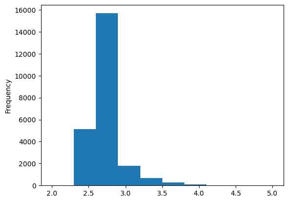

```python
# посмотрим график для наглядности

data['ceiling_height'].sort_values().plot(y = 'ceiling_height', kind = 'hist', bins = 10, range=(2,5))
plt.show()
```

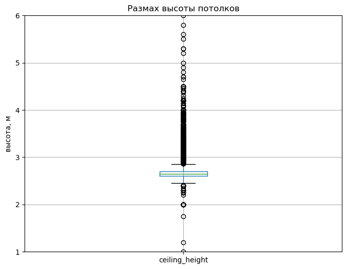

```python
# построим диаграмму размаха высоты потолков

data.boxplot(column='ceiling_height', figsize=(8, 6))
plt.title('Размах высоты потолков')
plt.ylim(1, 6)
plt.ylabel('высота, м')
plt.show()
```

*Из графика видно, значения менее 2,5м и более 2,8 метров - выбросы.*

```python
# оставим строки с высотой потолков от 2,5 до 5 метров

data = data.query('2.5 <= ceiling_height <= 5', engine='python')
```

**Посмотрим на столбец floors_total. Удалим строки с кол-вом этажей больше 30**

```python
# оставим строки с этажами < 30

data = data.query('floors_total < 30 or floors_total.isna()', engine='python')
```

```python
data['floors_total'].max()
```

```
29.0
```

**Вывод:**

Сделал предобработку данных, а именно:

- изменил типы данных,
- привел имена столбцов к единому стилю,
- обработал явные и неявные дубликаты,
- также обработал пропуски.

## Расчёты и добавление результатов в таблицу

### Произведем расчет данных и добавим их в таблицу для дальнейшего исследования:

1. **price_one_square_meter:** - цена одного квадратного метра;
2. **exposition_weekday:** - день недели публикации объявления (0 — понедельник, 1 — вторник и так далее);
3. **exposition_month:** - месяц публикации объявления;
4. **exposition_year:** - год публикации объявления;
5. **floor_category:** - тип этажа квартиры (значения — «первый», «последний», «другой»);
6. **city_centers_nearest_km:** - расстояние до центра города в километрах (переведем из м в км и округлим до целых значений).

#### Добавим столбец price_one_square_meter

```python
# добавим столбец с ценой за 1м²

data['price_one_square_meter'] = data['last_price'] / data['total_area']

# округлим полученную цену до копеек

data['price_one_square_meter'] = data['price_one_square_meter'].round(2)
data.sample(7)
```

|  | total_images | last_price | total_area | first_day_exposition | rooms | ceiling_height | floors_total | living_area | floor | is_apartment | studio | open_plan | kitchen_area | balcony | locality_name | airports_nearest | city_centers_nearest | parks_around_3000 | parks_nearest | ponds_around_3000 | ponds_nearest | days_exposition | price_one_square_meter |
| --- | --- | --- | --- | --- | --- | --- | --- | --- | --- | --- | --- | --- | --- | --- | --- | --- | --- | --- | --- | --- | --- | --- | --- |
| 1212 | 2 | 8 | 104.000000 | 2016-11-07 | 5 | 3.40 | 4.0 | 67.000000 | 2 | False | False | False | 10.0 | 0 | Санкт-Петербург | 25300.0 | 5718.0 | 2.0 | 381.0 | 0.0 | NaN | 466.0 | 0.08 |
| 1445 | 3 | 4 | 61.400002 | 2019-02-07 | 3 | 2.58 | 5.0 | 43.599998 | 1 | False | False | False | 7.4 | 0 | Санкт-Петербург | 17492.0 | 17697.0 | 0.0 | NaN | 0.0 | NaN | NaN | 0.07 |
| 9399 | 11 | 7 | 57.000000 | 2019-03-08 | 2 | 2.56 | 10.0 | 30.000000 | 7 | False | False | False | 9.0 | 3 | Санкт-Петербург | 12896.0 | 12430.0 | 1.0 | 719.0 | 1.0 | 26.0 | NaN | 0.12 |
| 8264 | 18 | 15 | 89.300003 | 2018-10-19 | 4 | 2.95 | 7.0 | 63.099998 | 2 | False | False | False | 10.0 | 0 | Санкт-Петербург | 25474.0 | 4322.0 | 1.0 | 379.0 | 3.0 | 616.0 | NaN | 0.17 |
| 23478 | 4 | 6 | 39.299999 | 2018-05-25 | 1 | 2.65 | 14.0 | 14.400000 | 4 | False | False | False | 10.9 | 2 | Санкт-Петербург | 19553.0 | 4762.0 | 0.0 | NaN | 1.0 | 533.0 | 147.0 | 0.15 |
| 14102 | 2 | 3 | 33.500000 | 2017-08-01 | 1 | 2.65 | 25.0 | 15.000000 | 15 | False | False | False | 9.0 | 0 | Кудрово | NaN | NaN | NaN | NaN | NaN | NaN | 504.0 | 0.09 |
| 16154 | 11 | 10 | 90.000000 | 2018-02-01 | 2 | 2.90 | 7.0 | 60.900002 | 1 | False | False | False | 9.3 | 0 | Санкт-Петербург | 10360.0 | 10297.0 | 2.0 | 320.0 | 0.0 | NaN | 112.0 | 0.11 |

#### Добавим столбец exposition_weekday, exposition_month, exposition_year

```python
# добавим столбец с днем недели публикации объявления
data['exposition_weekday'] = data['first_day_exposition'].dt.weekday

# добавим столбец с месяцем публикации объявления
data['exposition_month'] = data['first_day_exposition'].dt.month

# добавим столбец с годом публикации объявления
data['exposition_year'] = data['first_day_exposition'].dt.year
data.tail()
```

|  | total_images | last_price | total_area | first_day_exposition | rooms | ceiling_height | floors_total | living_area | floor | is_apartment | studio | open_plan | kitchen_area | balcony | locality_name | airports_nearest | city_centers_nearest | parks_around_3000 | parks_nearest | ponds_around_3000 | ponds_nearest | days_exposition | price_one_square_meter | exposition_weekday | exposition_month | exposition_year |
| --- | --- | --- | --- | --- | --- | --- | --- | --- | --- | --- | --- | --- | --- | --- | --- | --- | --- | --- | --- | --- | --- | --- | --- | --- | --- | --- |
| 23694 | 9 | 9 | 133.809998 | 2017-03-21 | 3 | 3.70 | 5.0 | 73.300003 | 3 | False | False | False | 13.830000 | 0 | Санкт-Петербург | 24665.0 | 4232.0 | 1.0 | 796.0 | 3.0 | 381.0 | NaN | 0.07 | 1 | 3 | 2017 |
| 23695 | 14 | 3 | 59.000000 | 2018-01-15 | 3 | 2.65 | 5.0 | 38.000000 | 4 | False | False | False | 8.500000 | 0 | Тосно | NaN | NaN | NaN | NaN | NaN | NaN | 45.0 | 0.05 | 0 | 1 | 2018 |
| 23696 | 18 | 2 | 56.700001 | 2018-02-11 | 2 | 2.65 | 3.0 | 29.700001 | 1 | False | False | False | NaN | 0 | село Рождествено | NaN | NaN | NaN | NaN | NaN | NaN | NaN | 0.04 | 6 | 2 | 2018 |
| 23697 | 13 | 11 | 76.750000 | 2017-03-28 | 2 | 3.00 | 17.0 | NaN | 12 | False | False | False | 23.299999 | 2 | Санкт-Петербург | 39140.0 | 10364.0 | 2.0 | 173.0 | 3.0 | 196.0 | 602.0 | 0.14 | 1 | 3 | 2017 |
| 23698 | 4 | 1 | 32.299999 | 2017-07-21 | 1 | 2.50 | 5.0 | 12.300000 | 1 | False | False | False | 9.000000 | 0 | посёлок Новый Учхоз | NaN | NaN | NaN | NaN | NaN | NaN | NaN | 0.03 | 4 | 7 | 2017 |

#### Добавим столбец с категоризацией по этажам floor_category

```python
# функция для категоризации этажности в доме

def get_floor_category(row):
    floor = row['floor']
    floors_total = row['floors_total']
    if floor == 1:
        return 'первый'
    elif floor == floors_total:
        return 'последний'
    else:
        return 'другой'
```

```python
# добавляем столбец с категорией этажа квартиры

data['floor_category'] = data.apply(get_floor_category, axis=1)
data.sample(3)
```

|  | total_images | last_price | total_area | first_day_exposition | rooms | ceiling_height | floors_total | living_area | floor | is_apartment | studio | open_plan | kitchen_area | balcony | locality_name | airports_nearest | city_centers_nearest | parks_around_3000 | parks_nearest | ponds_around_3000 | ponds_nearest | days_exposition | price_one_square_meter | exposition_weekday | exposition_month | exposition_year | floor_category |
| --- | --- | --- | --- | --- | --- | --- | --- | --- | --- | --- | --- | --- | --- | --- | --- | --- | --- | --- | --- | --- | --- | --- | --- | --- | --- | --- | --- |
| 9877 | 19 | 3 | 41.700001 | 2018-02-14 | 1 | 2.65 | 23.0 | 14.4 | 16 | False | False | False | 9.10 | 0 | Санкт-Петербург | 22425.0 | 24137.0 | 0.0 | NaN | 2.0 | 398.0 | 54.0 | 0.07 | 2 | 2 | 2018 | другой |
| 12271 | 3 | 6 | 69.000000 | 2018-08-08 | 2 | 2.65 | 20.0 | 55.0 | 14 | False | False | False | 13.73 | 0 | посёлок Мурино | NaN | NaN | NaN | NaN | NaN | NaN | 133.0 | 0.09 | 2 | 8 | 2018 | другой |
| 5153 | 9 | 3 | 47.799999 | 2019-04-03 | 2 | 3.00 | 5.0 | NaN | 2 | False | False | False | NaN | 0 | Санкт-Петербург | 13553.0 | 9058.0 | 0.0 | NaN | 0.0 | NaN | 23.0 | 0.06 | 2 | 4 | 2019 | другой |

#### Добавим столбец city_centers_nearest_km

```python
data['city_centers_nearest_km'] = round(data['city_centers_nearest'] / 1000)
data.head(4)
```

|  | total_images | last_price | total_area | first_day_exposition | rooms | ceiling_height | floors_total | living_area | floor | is_apartment | studio | open_plan | kitchen_area | balcony | locality_name | airports_nearest | city_centers_nearest | parks_around_3000 | parks_nearest | ponds_around_3000 | ponds_nearest | days_exposition | price_one_square_meter | exposition_weekday | exposition_month | exposition_year | floor_category | city_centers_nearest_km |
| --- | --- | --- | --- | --- | --- | --- | --- | --- | --- | --- | --- | --- | --- | --- | --- | --- | --- | --- | --- | --- | --- | --- | --- | --- | --- | --- | --- | --- |
| 0 | 20 | 13 | 108.000000 | 2019-03-07 | 3 | 2.70 | 16.0 | 51.000000 | 8 | False | False | False | 25.0 | 0 | Санкт-Петербург | 18863.0 | 16028.0 | 1.0 | 482.0 | 2.0 | 755.0 | NaN | 0.12 | 3 | 3 | 2019 | другой | 16.0 |
| 1 | 7 | 3 | 40.400002 | 2018-12-04 | 1 | 2.65 | 11.0 | 18.600000 | 1 | False | False | False | 11.0 | 2 | посёлок Шушары | 12817.0 | 18603.0 | 0.0 | NaN | 0.0 | NaN | 81.0 | 0.07 | 1 | 12 | 2018 | первый | 19.0 |
| 2 | 10 | 5 | 56.000000 | 2015-08-20 | 2 | 2.65 | 5.0 | 34.299999 | 4 | False | False | False | 8.3 | 0 | Санкт-Петербург | 21741.0 | 13933.0 | 1.0 | 90.0 | 2.0 | 574.0 | 558.0 | 0.09 | 3 | 8 | 2015 | другой | 14.0 |
| 3 | 0 | 64 | 159.000000 | 2015-07-24 | 3 | 2.65 | 14.0 | NaN | 9 | False | False | False | NaN | 0 | Санкт-Петербург | 28098.0 | 6800.0 | 2.0 | 84.0 | 3.0 | 234.0 | 424.0 | 0.40 | 4 | 7 | 2015 | другой | 7.0 |

**Вывод:**

Добавил необходимые столбцы и произвел расчеты по ним. Отмечу, что из-за пропусков в исходных данных, в расчетных значениях также есть пропуски. В столбце floor_category для 85 строк категория этажа могла определиться неверно (вместо последний -> другой), т.к. значения количества этажей для этих объектов отсутствуют. Учитывая то, что доля возможных ошибок крайне мала, на результаты исследования они не повлияют.

## Проведение исследовательского анализа данных:

**Изучение параметров объектов недвижимости**

### Общая площадь

```python
# посмторим описательную часть для столбца 'total_area'

data['total_area'].describe().T
```

```
count    23578.000000
mean        60.346542
std         35.572060
min         12.000000
25%         40.000000
50%         52.000000
75%         70.000000
max        900.000000
Name: total_area, dtype: float64
```

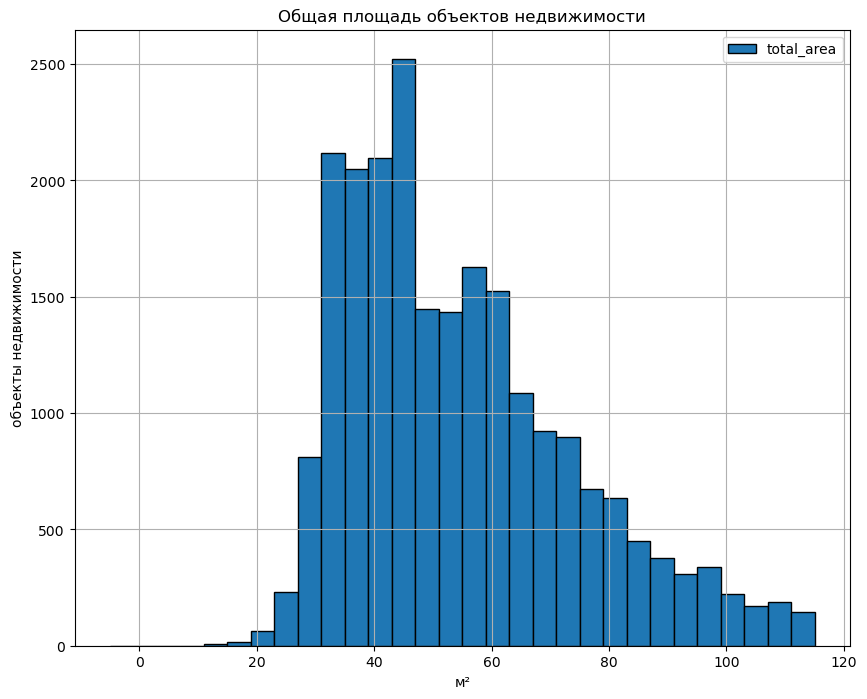

```python
# рассчитаем Q1, Q3 и IQR чтобы построить график без выбросов
# первый квартиль Q1
q1 = data['total_area'].quantile(.25)

# третий квартиль Q3
q3 = data['total_area'].quantile(.75)

# межквартильный размах IQR
iqr = q3 - q1

# построим гистограмму площади
data['total_area'].hist(bins=30, range=((q1 - 1.5 * iqr), (q3 + 1.5 * iqr)), figsize=(10, 8), ec='black', legend=True)
plt.title('Общая площадь объектов недвижимости')
plt.xlabel('м²')
plt.ylabel('объекты недвижимости')
plt.show()
```

### Жилая площадь

```python
# посмторим описательную часть для столбца 'living_area'

data['living_area'].describe()
```

```
count    21684.000000
mean        34.458401
std         22.011629
min          2.000000
25%         18.600000
50%         30.000000
75%         42.299999
max        409.700012
Name: living_area, dtype: float64
```

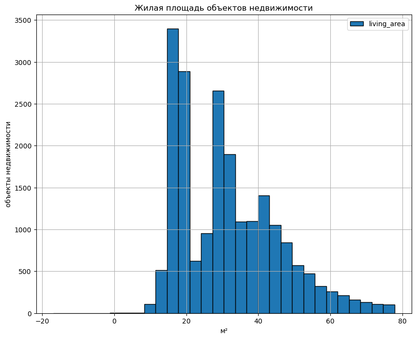

```python
# рассчитаем Q1, Q3 и IQR чтобы построить график без выбросов
# первый квартиль Q1
q1 = data['living_area'].quantile(.25)

 # третий квартиль Q3
q3 = data['living_area'].quantile(.75)

# межквартильный размах IQR
iqr = q3 - q1

# построим гистограмму площади
data['living_area'].hist(bins=30, range=((q1 - 1.5 * iqr), (q3 + 1.5 * iqr)), figsize=(10, 8), ec='black', legend=True)
plt.title('Жилая площадь объектов недвижимости')
plt.xlabel('м²')
plt.ylabel('объекты недвижимости')
plt.show()
```

**Вывод:**

Рассматриваемый диапазон, до примерно 78 м², исключая выбросы. Большая часть объектов недвижимости имеют жилую площадь от 15 до 35 м². Самый распространенный вариант - около 15 м². Жилая площадь объектов более 60 м² встречается редко. С площадью меньше 15 м² также редкость. Среднее значение - 34 м², медиана 30 м². У графика также наблюдается "хвост" из-за редких, но больших значений.